# chapter2 ― 確率分布と統計モデルの最尤推定

KADOWAKI, Shuhei

2018/11/26

```r
print('hello R world and statistical modeling !')
```

```
[1] "hello R world and statistical modeling !"
```

# 1 basic operations

```r
load('../data/data2.RData')
print(data)
```

```
 [1] 2 2 4 6 4 5 2 3 1 2 0 4 3 3 3 3 4 2 7 2 4 3 3 3 4 3 7 5 3 1 7 6 4 6 5
[36] 2 4 7 2 2 6 2 4 5 4 5 1 3 2 3
```

```r
print(length(data))
```

```
[1] 50
```

```r
print(summary(data))
```

```
   Min. 1st Qu.  Median    Mean 3rd Qu.    Max.
   0.00    2.00    3.00    3.56    4.75    7.00
```

```r
print(table(data))
```

```
data
 0  1  2  3  4  5  6  7
 1  3 11 12 10  5  4  4
```

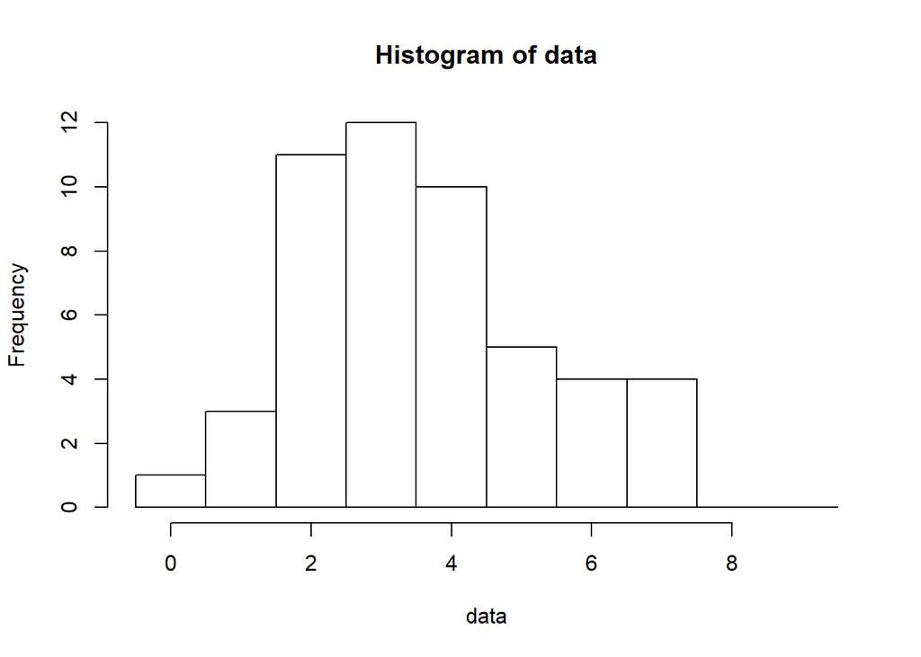

```r
hist(data, breaks = seq(-0.5, 9.5, 1))
```

```r
var(data)
```

```
[1] 2.986122
```

```r
mean(data)
```

```
[1] 3.56
```

```r
sd(data)
```

```
[1] 1.72804
```

```r
sqrt(var(data))
```

```
[1] 1.72804
```

## 1.1 probability distribution

確率分布: **確率変数**(random variable)の値とそれが出現する確率を対応させたもの

とりあえずポアソン分布(Poisson distribution)なるものを見てみる

$$p(y|\lambda) = \frac{\lambda^y \exp(-\lambda)}{y!}$$
$p(y|\lambda)$: 平均が$\lambda$であるときに, ポアソン分布に従う確率変数が$y$という値になる確率 $\lambda$: ポアソン分布唯一のパラメータ

- ポアソン分布の性質
  - 全ての和は1: $\sum_{y=0}^{\infty} p(y|\lambda) = 1$
  - (分散)=(平均)=$\lambda$
- ポアソン分布を選ぶ理由
  - データがカウントデータ(非負の整数)
  - $y$に下限(0)はあるが, 上限はわからない
  - 観測データの平均と分散がだいたい等しい

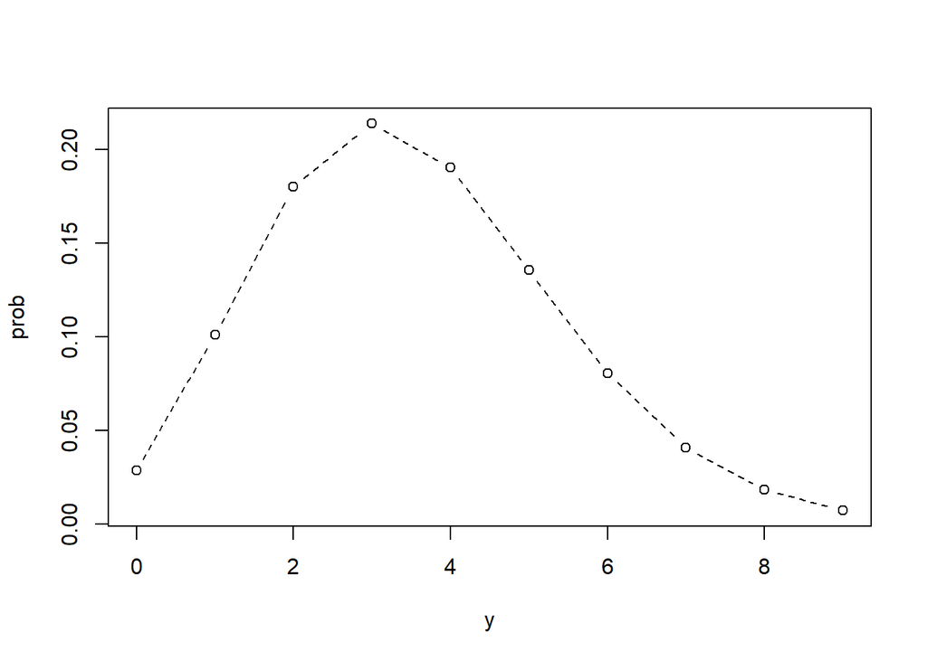

```
 [1] 0.02843882 0.10124222 0.18021114 0.21385056 0.19032700 0.13551282
 [7] 0.08040427 0.04089132 0.01819664 0.00719778
```

```r
y <- 0:9
prob <- dpois(y, lambda = 3.56)
print(prob)
plot(y, prob, type = 'b', lty = 2)
```

重ねて描写してみる

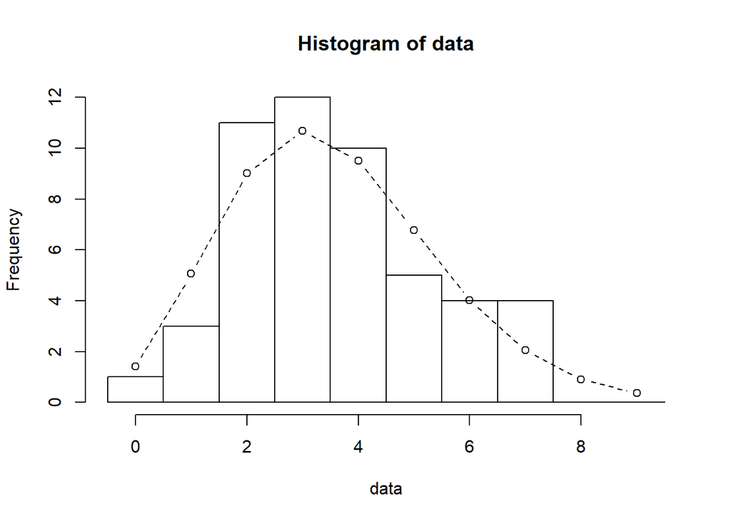

```r
hist(data, breaks = seq(-0.5, 9.5, 1))
lines(y, length(data) * prob, type = 'b', lty = 2)
```

# 2 maximum likelihood estimation

対数尤度と$\log L(\lambda)$と$\lambda$の関係を図示する

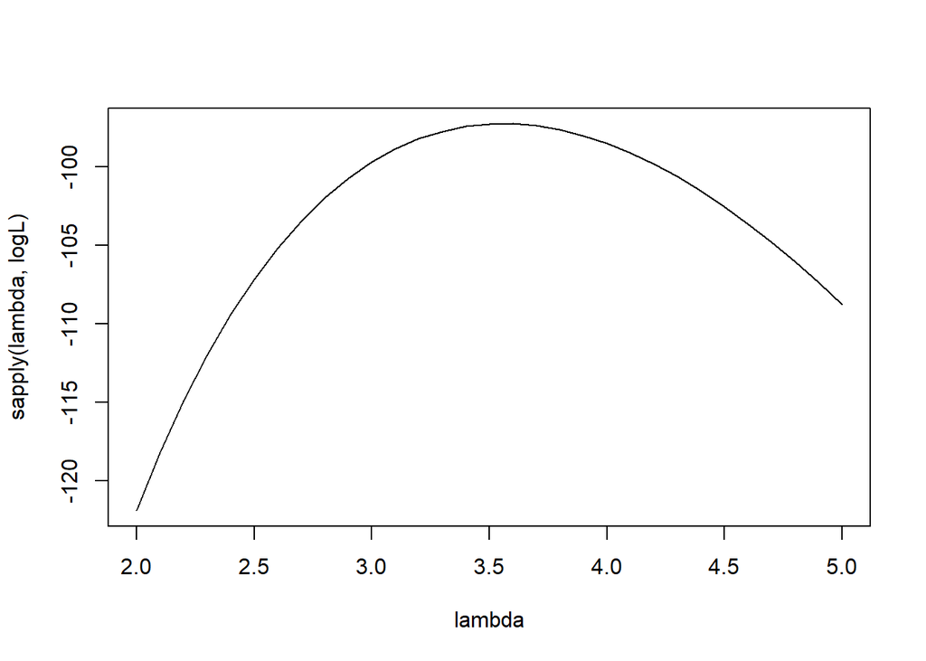

```r
logL <- function(m) sum(dpois(data, m, log = TRUE))
lambda <- seq(2, 5, 0.1)
plot(lambda, sapply(lambda, logL), type = 'l')
```

# 3 standard error

- 標準誤差: 推定値の不確かさを表す量
  - 最尤推定値のばらつき
  - 「真のモデル」を知らないと使えない
    - ふつうは知らない => たまたま得られた観測データから推定されただけの値を用いて行う(意味あるの?)

# 4 sampling, estimation, prediction

- 統計モデリングの流れ
  1. データ(標本)を発生(**sampling**)させた確率分布(「真の統計モデル」)を考える
  2. パラメータを**推定**する(**estimation**, あるいは「**あてはめ**」(**fitting**))
  3. 同じsampling方法で得られる次のデータの分布を見積もる(**予測**, **prediction**)
- predictionの種類
  - 次に得られる応答変数の平均だけを示す
    - 「回帰直線を引く」なども含まれる
  - 次に得られるデータはこの範囲に散らばるはずだという予測区間も示す
  - 将来予測(時系列構造データ), 欠損予測(空間構造データ)

# 5 probability distribution (again)

- まず「この現象がどのような確率分布で説明されそうか」を考える
- 次の点に注意
  - 離散 or 連続
  - 範囲
  - 標本分散と標本平均の関係
- examples
  - ポアソン分布(Poisson distribution): 離散, 0以上上限なし, 平均≈分散
  - 二項分布(binomial distiribution): 離散, 0以上有限, 分散は平均の関数
  - 正規分布(normal distribution): 連続, 無限小から無限大, 分散は平均と無関係
  - ガンマ分布(gamma distribution): 連続, 0から無限大, 分散は平均の関数